# SMEs Scaling up in Denmark: Country note

OECD, Centre for Entrepreneurship, SMEs, Regions and Cities (CFE)

2024-04-12

## Scalers and the economy

*A small group of SMEs that grow fast over a short period of time, i.e. “scalers”, provide a large part of the growth in jobs and economic value in OECD countries. This section contains an overview of the recent trends in the number of scalers in Denmark and benchmark their contributions to job and value creation with other countries.*

### Around one fifth of Danish SMEs are scalers

In Denmark, about 4 900 small or medium-sized enterprises (SMEs) became scalers between 2017 and 2020, accounting for 18% of the 26 000 SMEs in the non-financial business sector. Among those, about 2 800 were scalers in employment, 4 100 were scalers in turnover, and 2 000 were scalers in both employment and turnover.

Scalers in year 2020 are defined as enterprises with 10 to 249 employees (SMEs) that increased employment or turnover by at least 10% per year, on average, over the three previous years (2017-20). This means they grow by at least 33% over the three-year period.

The number of scalers in employment grew by 42% from 2014 to 2016, and increased further until 2018, surpassing 4 200. The number of scalers in turnover also peaked in 2016-17, reaching above 5 000 units. The upward trend reflects a period of economic expansion across the OECD in the wake of the Global Financial Crisis. The number of scalers declined sharply in 2020 as the COVID-19 pandemic spread. The reason is that SMEs that grew in 2018 and 2019 and were on track to become scalers by 2020 were unable to continue growing and might even had to reduce output or employment.

High-growth scalers, defined as SMEs with annual growth rates exceeding 20% over three consecutive years, may exhibit distinct trends through economic cycles. Compared to other scalers, high-growth scalers may be faster to react to economic shifts and new market opportunities, but they may also be more constrained by lack of financial resources or tight labour markets. About one in three scalers grows by more than 20% per year on average over three consecutive years, qualifying as “high-growth” scalers. In 2020, there were almost 1 000 high-growth scalers in employment and 1 700 high-growth scalers in turnover. The number of high-growth scalers in employment peaked in 2017-18, surpassing the 1 700 units. High-growth scalers in turnover had a more gradual evolution, counting more than 2 000 over the entire 2014-19 period.

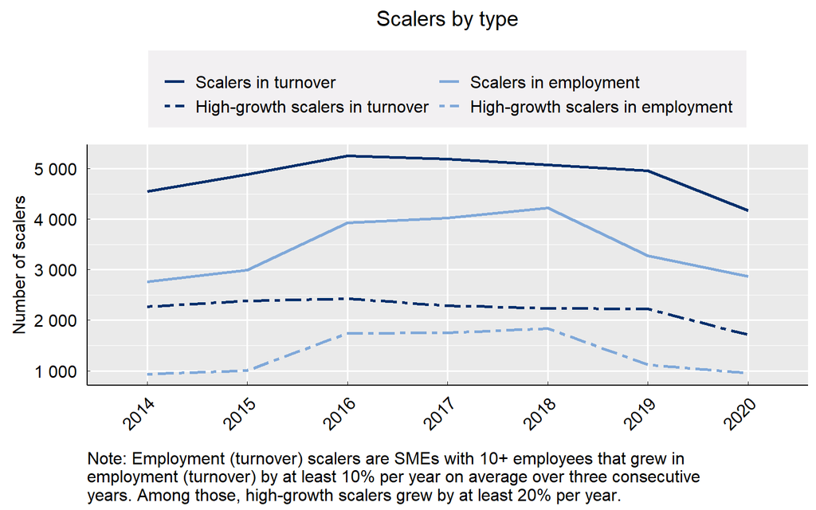

### Scalers in employment created 72 000 additional jobs over three years

In Denmark, scalers in employment created 72 000 jobs over the 2017-20 period, which accounts to 9.5 additional jobs for every 100 workers in SMEs in 2017. The contribution is aligned with the average of other countries for which data are available.

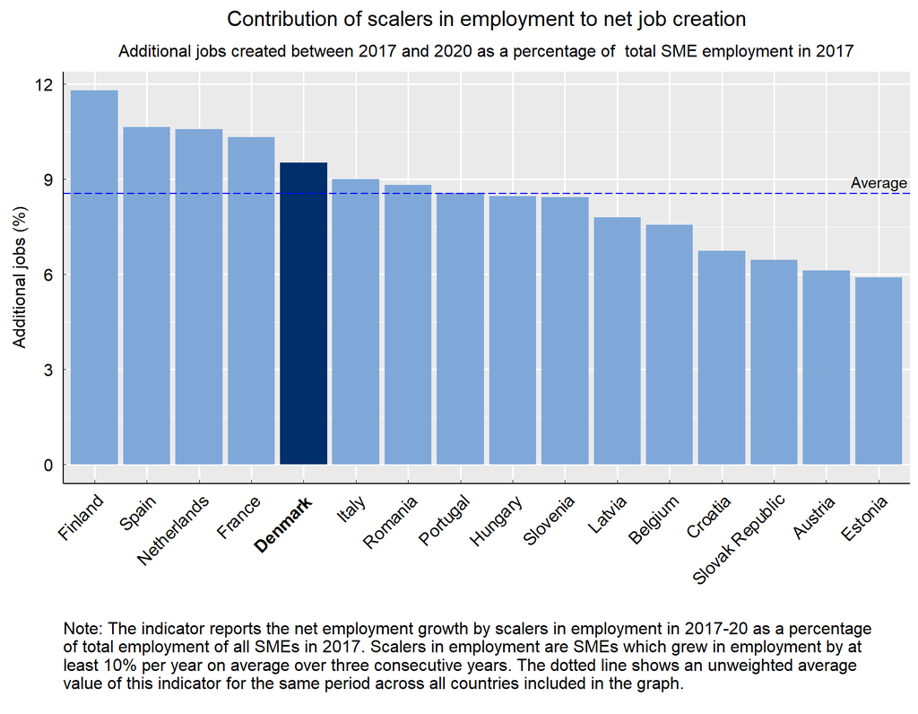

### Scalers in turnover increased SMEs’ total turnover by 15%

The total turnover of Danish scalers in turnover in 2020 was EUR 31 billion larger than in 2017. The increase corresponds to 15% of the total turnover of Danish SMEs in 2017. This compares to 12% on average across countries with available data, indicating that the contribution of scalers in turnover to value creation is about 25% larger in Denmark.

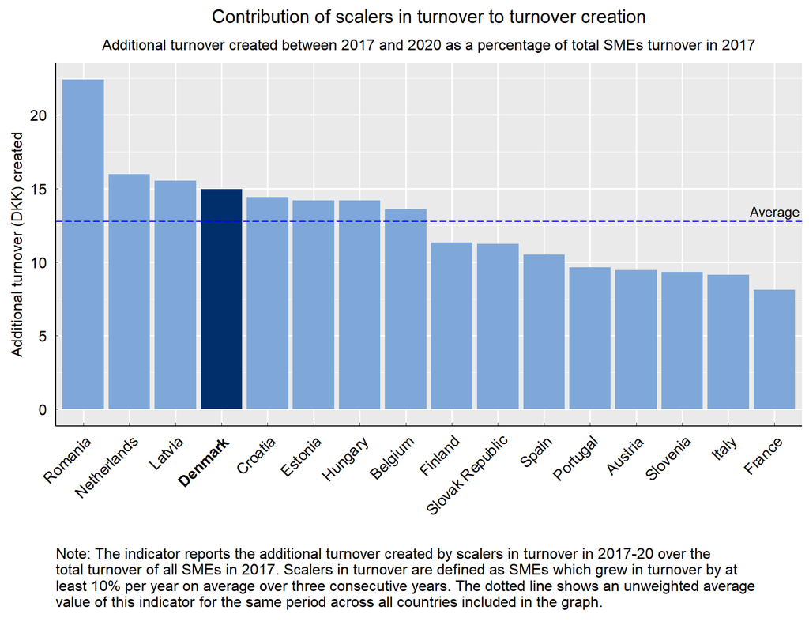

## Scalers’ characteristics

*All types of SMEs can scale up. This section describes the characteristics of scalers in terms of sector of activity, size, age, and geographical distribution. It also compares the likelihood of SMEs to scale up in Denmark and in other countries across different groups of SMEs.*

### Most Danish scalers operate in services and construction

Sector groups include the following two-digit NACE sectors:

• Low and medium-low technology manufacturing and extractive industries: food, textile, paper, wood, refined petroleum, rubber, plastic, basic metal products, mining.

• Medium-high and high technology manufacturing: chemical products, pharmaceuticals, computer, electronic/electrical equipment, machinery, transport equipment.

• Advanced tradable services: software, telecommunications, consultancy, legal services, accounting services, architectural activities, scientific research.

• Other tradable services: travel agency, services to buildings/landscape, employment activities, veterinary, accommodation/food services, services for transportation.

• Other non-tradable services: electricity, gas and water supply, waste management, wholesale and retail trade, repair of motor vehicles/household goods, real estate activities.

• Education, social care and health services: Education, human health activities, residential care, social work.

• Construction: construction of buildings, civil engineering, specialised construction activities.

Source: Manufacturing sectors are aggregated using Eurostat’s high-technology classification of manufacturing industries. The classification of tradable and non-tradable services is based on Piton, S. (2021). Economic integration and unit labour costs. European Economic Review, 136, 103746.

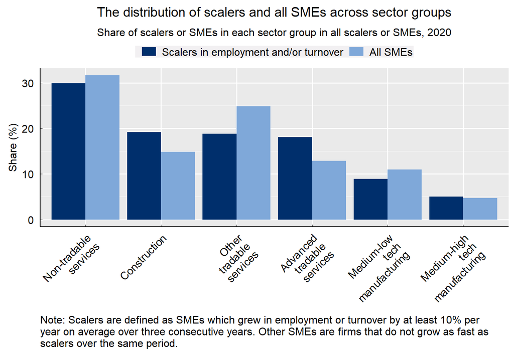

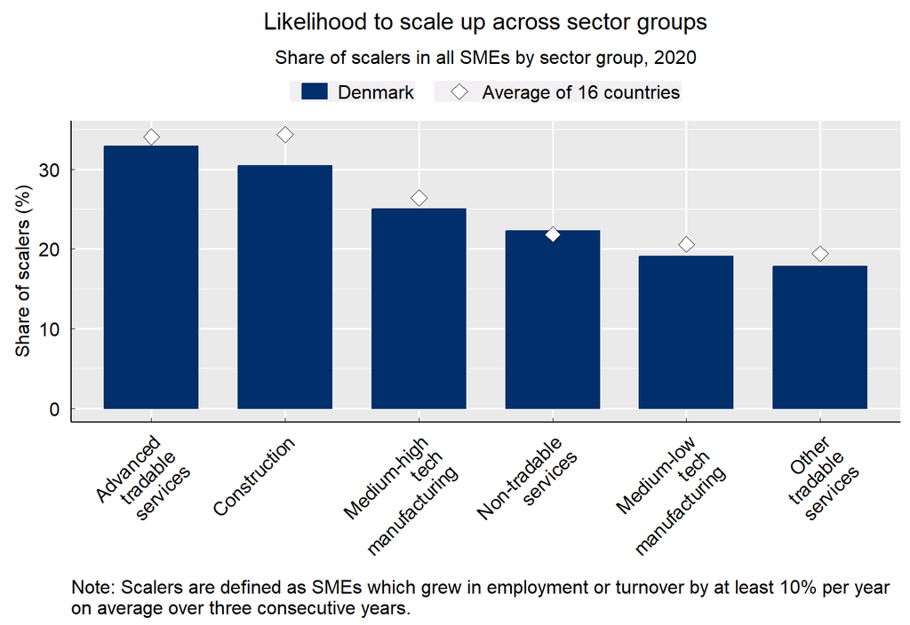

### SMEs of all sizes scale up

More than half of Danish scalers have between 10 and 19 employees at the beginning of the growth period, and almost one third have between 20 and 49 employees. Only 5% of scalers have between 100 and 249 employees before the expansion phase. The similar distribution of scalers and SMEs across size classes implies that the likelihood to scale up is not very different between smaller and larger SMEs. About 24% of SMEs in the 10-19 size class become scalers, compared to 19% of SMEs in the 100-249. Differences in the likelihood to scale up across size classes in Denmark are aligned with the cross-country averages.

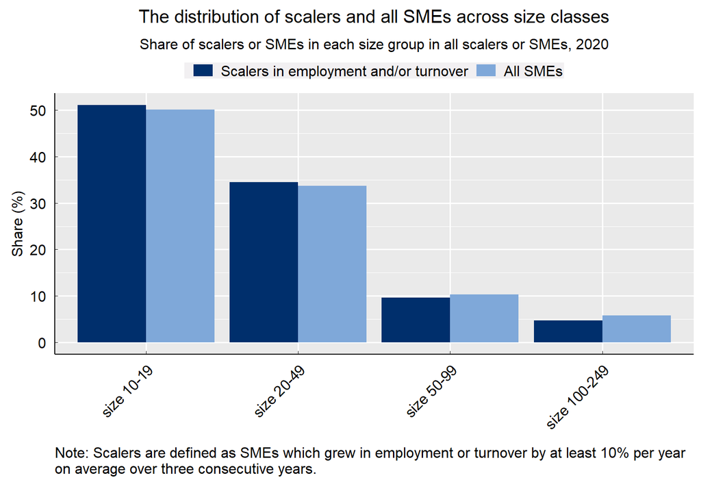

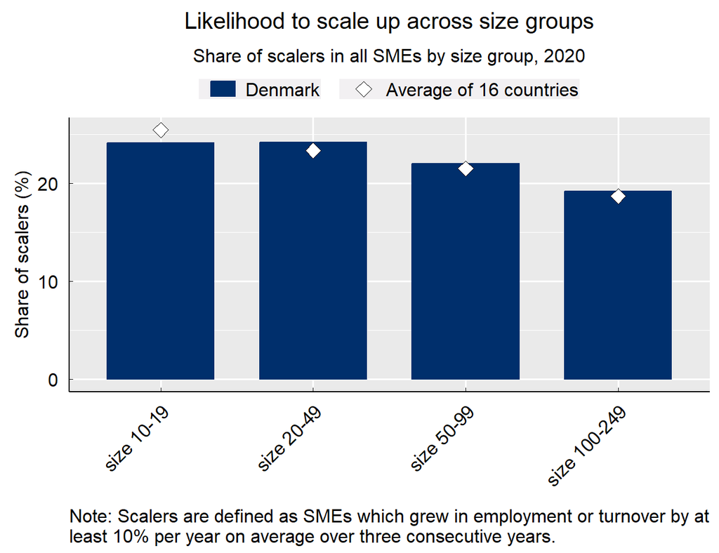

### Most Danish scalers are mature SMEs

Most Danish scalers (72%) are mature SMEs that are more than 10 years old at the beginning of the scale up period. 14% of scalers are less than 6 years old (i.e. young) and the rest (13%) are between 6 and 10 years old. In contrast, 80% of comparable SMEs are mature and 9% are young.

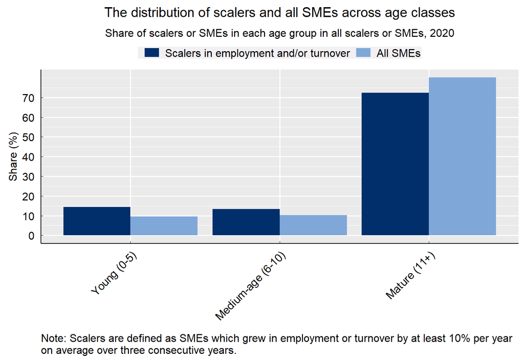

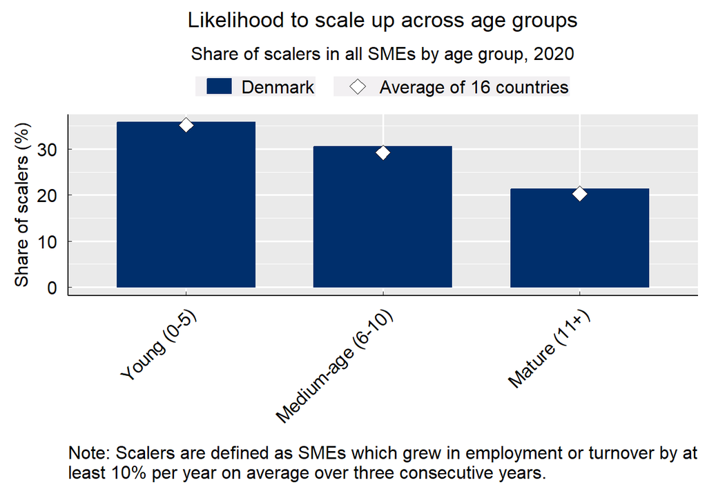

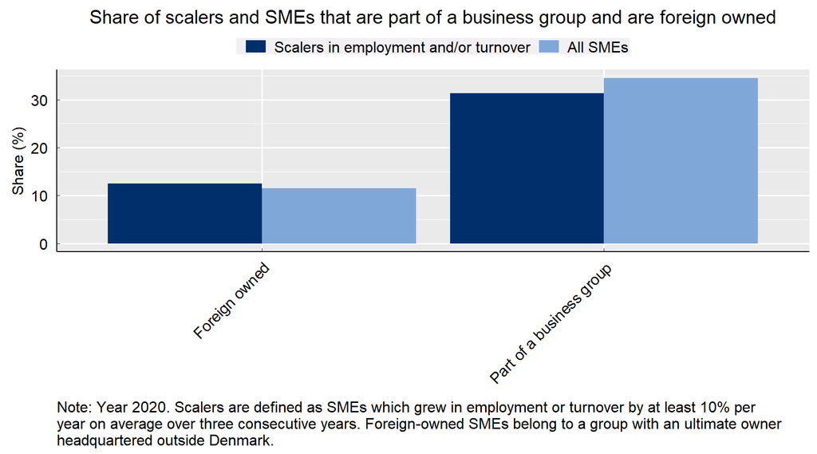

## Growth trajectories

*While many SMEs consolidate at their new size after scaling up, rapid growth also brings new challenges, with some scalers failing to adapt. This section illustrates the growth trajectories of scalers in the three years following their (first) expansion phase.*

### The majority of scalers maintained their new size or even continued to grow

Between 2016 and 2019, 12% of Danish scalers in employment continued to scale up in employment after a first scaling up in the previous three years. These 280 firms employed 12 000 more people after six years. Among scalers in turnover, 19% achieved two high-growth periods in a row, reaching a total turnover that was 316% higher in 2019 compared to 2013.

In addition, 49% of scalers in employment and 36% of scalers in turnover maintained their size or grew moderately in the following three years.

The share of scalers that consolidated at the new size or continued growing in Denmark was below the average value across the other countries with available data. In particular, Denmark is characterised by a low rate of scalers having a second expansion phase compared to other countries.

### One in three scalers contracted after scaling up

Scaling up also brings challenges for SMEs. Firms may need to comply with stricter regulations, improve their managerial practices, or adopt a different financial model. Some scalers may struggle to adapt and experience a contraction after growing. In Denmark, 29% of SMEs that scale up in employment between 2013 and 2016 reduced their workforce over the following three years. Similarly, 37% of scalers in turnover had a lower turnover three years after scaling up, underscoring the challenges inherent in maintaining an expanded scale.

Together with Belgium and Romania, Denmark belongs to the group of countries with more than 25% of scalers in turnover reversing in turnover growth after a first scaling-up phase. This trend towards easier downscaling in turnover might reflect a more volatile business environment for SMEs, potentially linked to heightened dependency on foreign markets or other external economic factors influencing the stability of growth among SMEs.

### One in ten scalers was inactive three years after scaling up

For 8% of scalers in employment and 6% of scalers in turnover, there was no information available on their employment or turnover levels in 2019. This lack of information is open to different interpretations. First, the firm may be closed or about to close, which in most cases indicates that the business has not been successful. Second, the lack of information may simply be a “nuisance” in the data, e.g. due to reporting errors. In addition, around 2% of scalers appear to have been acquired by another company in the three years after the expansion phase, which is often a successful outcome for the business owners. These scalers are excluded from the sample used to identify the trajectories after scaling up discussed above.

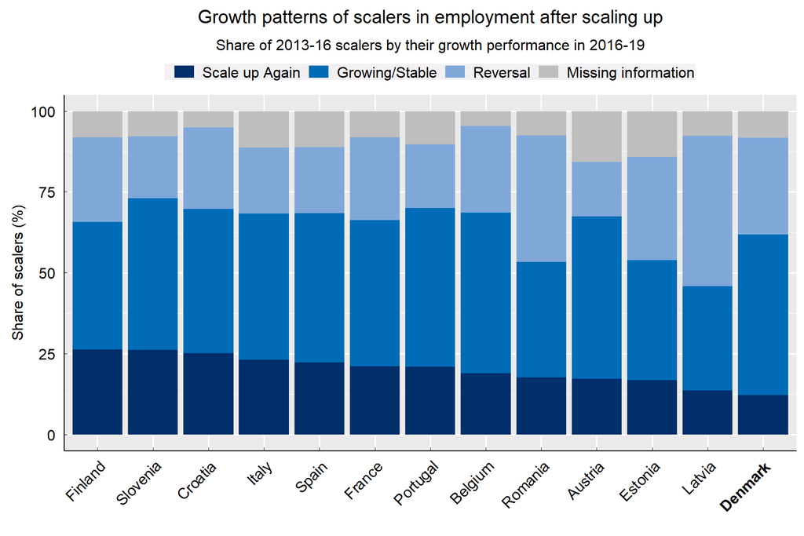

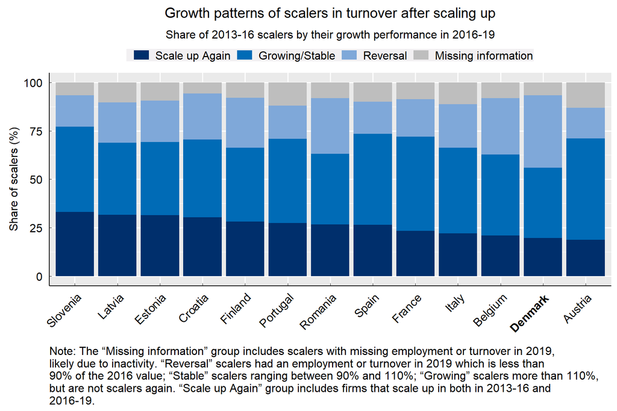